# Recap on selected statistical concepts

Last updated in February 2022

## Recap on selected concepts in statistics

## Probability distribution

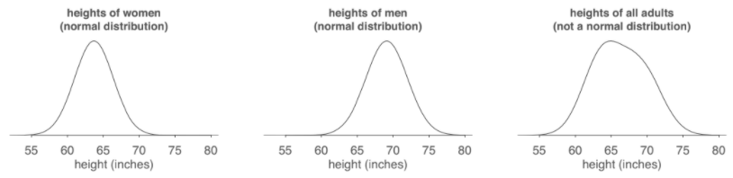

Source: (Gelman et al., 2020, p. 41)

For each distribution of a variable z, we can calculate the mean, a.k.a. the expected value written as E(z) or μ<sub>z</sub> to refer specifically to population mean or \(\overline{x}\) to refer to sample mean.

## The variance of distribution

Variance = expected value of the squared deviation from the mean.

\[ var(z) = E[(z_i-\mu_z)^2] = \frac{\sum (z_i - \bar{z})^2}{n} \]

We typically work with the standard deviation rather than the variance because it is on the original scale of the distribution.

\[ \sigma_z = \sqrt{var{(z)}} \]

## Visual representation is often preferred to understand variability in the variable

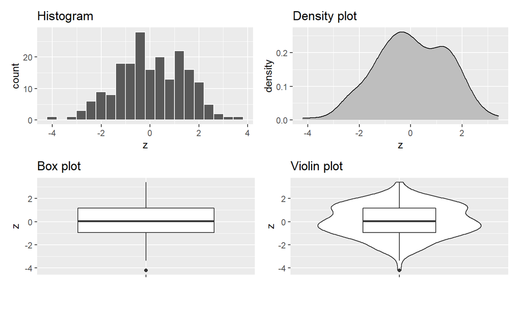

## Sampling distribution 1/2

“The sampling distribution is the set of possible datasets that could have been observed if the data collection process had been re-done, …” (Gelman et al., 2020, p. 50)

## Sampling distribution 2/2

- Standard deviation of the distribution of a given estimate is called standard error = \(\frac{\sigma}{\sqrt n}\).
- Confidence intervals are extension of standard errors, see picture below (beta-hat is the estimate of the regression coefficient beta from the data).

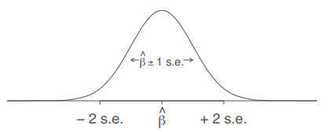

If the model is correct, then in repeated applications 95% confidence intervals will include the true value 95% of the time

Source: (Gelman et al., 2020, p. 51)

## T-distribution

- Student’s t-distribution a.k.a. just t-distribution is used for statistical significance testing of estimates coming from a sampling distribution
- Similar to normal (symmetric), but heavier tails, three parameters: center, scale, degrees of freedom
- Converges to normal with large N (30 and more)

## Statistical significance and hypothesis testing

- Conventional wisdom: statistical significance is p-value less than 0.05, relative to some null hypothesis (hypothesis of no difference / no effect)
- Intuition behind it: an estimate is said to be NOT statistically significant if the observed value could reasonably be explained by chance

## Null-hypothesis testing (NHT)

- null hypothesis: estimate = 0
- alternative hypothesis: estimate != 0
- p-value: “the probability under a specified statistical model that a statistical summary of the data (e.g., the sample mean difference between two compared groups) would be equal to or more extreme than its observed value” (Wasserstein & Lazar, 2016, pp.)

## Type 1 and type 2 error in NHT

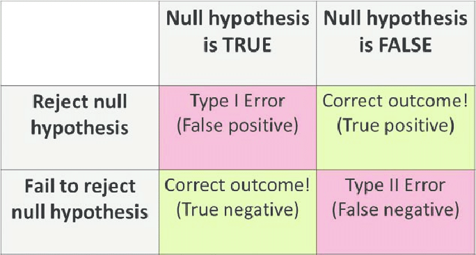

Source https://www.researchgate.net/figure/Graphical-representation-of-type-1-and-type-2-errors_fig1_268035363

- type 1 error: the probability of falsely rejecting a null hypothesis, if it is in fact true
- type 2 error: the probability of not rejecting a null hypothesis that is in fact false

[figure not shown]

## Covariance

Measure of joint variability in a linear relationship between two variables.

\[ var(x) = E[(x_i - \mu_x)^2] = E[(x_i - \mu_x)*(x_i - \mu_x)] = \\ \frac{\sum[(x_i - \mu_x)*(x_z-\mu_x)]}{n} \]

\[ cov(x) =E[(x_i - \mu_x)*(y_i - \mu_y)] = \\ \frac{\sum[(x_i - \mu_x)*(y_i-\mu_y)]}{n} \]

## The value of covariance is rarely useful as the end product

For a set of selected countries:

```
> The covariance of life expectancy and proportion of university degree is 0.11814756302521
```

```
> The covariance of population and area is 3593964491151.22
```

## Correlation is standardized covariance

```
> The correlation of life expectancy and proportion of university degree is 0.54
```

```
> The correlation of population and area is 0.78
```

## Visual perception of correlation strength

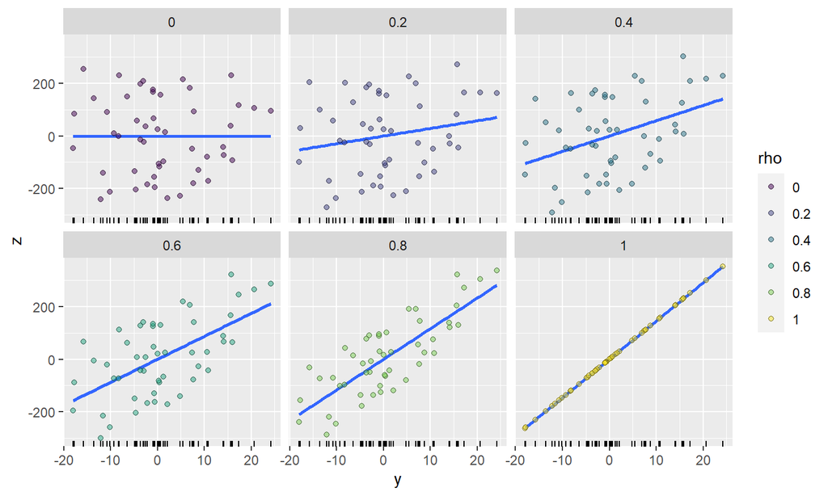

Code by whuber from: https://stats.stackexchange.com/questions/15011/generate-a-random-variable-with-a-defined-correlation-to-an-existing-variables

## The difference between correlation and regression coefficient

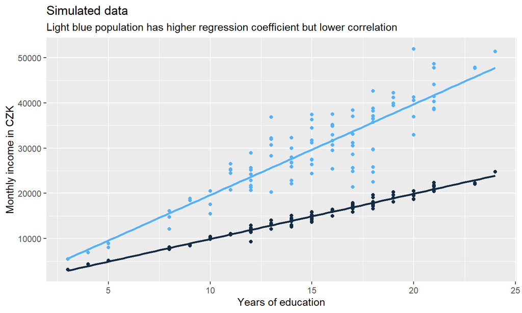

## Visual representation to understand association between two variables

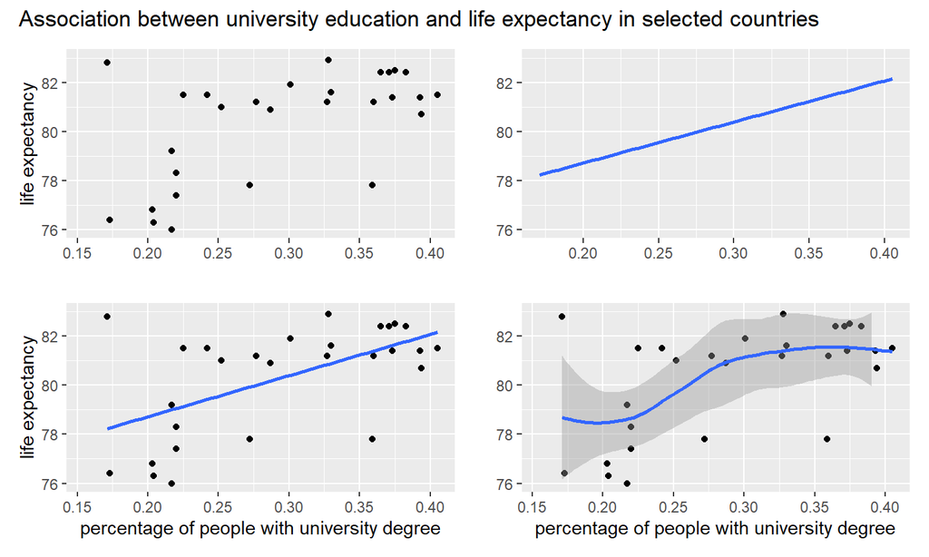

## Critique of Null Hypothesis Testing

## Critique of NHT 1/3

- NH is unrealistic in social sciences (only a matter of sample size)
- NH is theoretically uninteresting (effect size and variations of effect sizes in different groups is)
- NH is a very low threshold - non-rejection tells us that there is not even enough information in the data to move beyond the banal null hypothesis
- Even statistically non-significant data can carry important information (not just for meta-analysis)

## Critique of NHT 2/3

- p-value is often used as a license for making a claim of a scientific finding (or implied truth) while neglecting many other important considerations (“design of a study, the quality of the measurements, the external evidence for the phenomenon under study, and the validity of assumptions that underlie the data analysis” (Wasserstein & Lazar, 2016)
- p-value is often used incorrectly (significance chasing a.k.a. p-hacking): (1) multiple statistical tests, (2) choice of data to be presented based on statistical-significance result
- p-value is often interpreted incorrectly (such as when non-significant p-value is considered evidence for no difference)
- there is (usually almost) no difference between 5.1% and 4.9% significance level

## Critique of NHT 3/3

See the ASA statement which links to plenty of other relevant literature on p-value (Wasserstein & Lazar, 2016)

Gelman, A., Hill, J., & Vehtari, A. (2020). *Regression and other stories*. Cambridge University Press. https://doi.org/10.1017/9781139161879

Wasserstein, R. L., & Lazar, N. A. (2016). The ASA statement on p-values: Context, process, and purpose. *The American Statistician*, *70*(2), 129–133. https://doi.org/10.1080/00031305.2016.1154108